# Projekt z Uczenia Maszynowego

Julia Pawluś, Karolina Szot - IiE, grupa 2

```r
library(ingredients)
library(glmnet)
library(DALEX)
library(gridExtra)
```

```r
library(ggplot2)
library(corrplot)
library(pROC)
library(ipred)
library (rpart)
library(randomForest)
library(readr)
library(tidyverse)
library(rpart)
library(rpart.plot)
library(caret)
library(ipred)
library('e1071')
library(glmnet)
library(dplyr)
library(gbm)
library(ROSE)
dane_snieg <- read.csv("Krakow_11_snieg.csv")
head(dane_snieg)
```

```
##          id        miasto  rok miesiac dzien zachmurzenie wiatr temperatura_min
## 1 350190566 KRAKOW-BALICE 2023      11     1          4.5   3.3             6.6
## 2 350190566 KRAKOW-BALICE 2023      11     2          4.4   3.5             2.8
## 3 350190566 KRAKOW-BALICE 2023      11     3          7.3   5.1             9.8
## 4 350190566 KRAKOW-BALICE 2023      11     4          3.6   2.6             5.4
## 5 350190566 KRAKOW-BALICE 2023      11     5          5.8   1.8             1.0
## 6 350190566 KRAKOW-BALICE 2023      11     6          3.6   6.9             5.9
##   temperatura_max temperatura wilgotnosc cisnienie rosa szron mgla zamglenie
## 1            14.6         9.9       83.0     982.2  4.0     0  0.0       0.0
## 2            17.9         9.6       76.9     973.8 14.3     0  0.0       0.0
## 3            14.2        12.3       75.4     961.6  0.0     0  0.0       0.0
## 4            14.5         7.7       73.3     967.9  0.0     0  0.0       1.7
## 5             9.2         6.0       93.8     961.9  0.0     0  1.7       2.4
## 6            13.6        10.3       70.4     976.8  0.0     0  0.0       0.7
##   zmetnienie wiatr10 snieg pokrywa_sniezna deszcz
## 1          0     0.0     0               0    0.0
## 2          0     0.0     0               0    1.0
## 3          0     0.3     0               0    0.3
## 4          0     0.0     0               0    0.0
## 5          0     0.0     0               0    6.4
## 6          0     6.4     0               0    0.4
```

Dane wykorzystane w zadaniu zostały pobrane ze zbioru danych publicznych, udostępnionych przez IMGW. Obserwacje pochodzą ze stacji synoptycznej o numerze 350190566, która znajduje się na lotnisku Kraków Balice, i jest główną stacją zbierającą informacje o warunkach atmosferycznych dla miasta Krakowa. Pomiary mają charakter dobowy i są zebrane dla jednego miesiąca - listopada, na przestrzeni lat 2010 - 2023, co daje łącznie 420 dni.

Zbiór danych udostępnionych przez IMGW zawiera wszystkie parametry warunków atmosferycznych, które są odnotowywane na stacjach meteorologicznych. Dane zostały oczyszczone ze zbędnych zmiennych, takich jak: czas trwania deszczu ze śniegiem czy wystąpienie błyskawicy, gdyż takie zjawiska, nawet na przestrzeni kilku lat, odnotowywane są zbyt rzadko aby miały istotny wpływ na badanie. Usunięto również zmienne, które nie są zaliczane do podstawowych zjawisk atmosferycznych np. temperatura minimalna przy gruncie czy stan gruntu, gdyż ich wpływ na model prognozy pogody nie będzie miał praktycznego wymiaru.

```r
dane_snieg$rosa_01 <- ifelse(as.numeric(dane_snieg$rosa) >= 0.5, 1, 0)
dane_snieg$szron_01 <- ifelse(as.numeric(dane_snieg$szron) >= 0.5, 1, 0)
dane_snieg$mgla_01 <- ifelse(as.numeric(dane_snieg$mgla) >= 0.5, 1, 0)
dane_snieg$wiatr10_01 <- ifelse(as.numeric(dane_snieg$wiatr10) >= 0.5, 1, 0)
dane_snieg$pokrywa_sniezna_01 <- ifelse(as.numeric(dane_snieg$pokrywa_sniezna) >= 0.1, 1, 0)
dane_snieg$deszcz_01 <- ifelse(as.numeric(dane_snieg$deszcz) >= 0.5, 1, 0)
dane_snieg$zmetnienie_01 <- ifelse(as.numeric(dane_snieg$zmetnienie) >= 0.5, 1, 0)
dane_snieg$zamglenie_01 <- ifelse(as.numeric(dane_snieg$zamglenie) >= 0.5, 1, 0)
dane_snieg$snieg_prognoza <- ifelse(as.numeric(dane_snieg$snieg) >= 0.1, 1, 0)


head(dane_snieg)
```

```
##          id        miasto  rok miesiac dzien zachmurzenie wiatr temperatura_min
## 1 350190566 KRAKOW-BALICE 2023      11     1          4.5   3.3             6.6
## 2 350190566 KRAKOW-BALICE 2023      11     2          4.4   3.5             2.8
## 3 350190566 KRAKOW-BALICE 2023      11     3          7.3   5.1             9.8
## 4 350190566 KRAKOW-BALICE 2023      11     4          3.6   2.6             5.4
## 5 350190566 KRAKOW-BALICE 2023      11     5          5.8   1.8             1.0
## 6 350190566 KRAKOW-BALICE 2023      11     6          3.6   6.9             5.9
##   temperatura_max temperatura wilgotnosc cisnienie rosa szron mgla zamglenie
## 1            14.6         9.9       83.0     982.2  4.0     0  0.0       0.0
## 2            17.9         9.6       76.9     973.8 14.3     0  0.0       0.0
## 3            14.2        12.3       75.4     961.6  0.0     0  0.0       0.0
## 4            14.5         7.7       73.3     967.9  0.0     0  0.0       1.7
## 5             9.2         6.0       93.8     961.9  0.0     0  1.7       2.4
## 6            13.6        10.3       70.4     976.8  0.0     0  0.0       0.7
##   zmetnienie wiatr10 snieg pokrywa_sniezna deszcz rosa_01 szron_01 mgla_01
```

[output cut: 20 more lines]

```r
createDataSnieg <- function() {

  dane_snieg$zachmurzenie <- as.numeric(dane_snieg$zachmurzenie)
  dane_snieg$wiatr <- as.numeric(dane_snieg$wiatr)
  dane_snieg$temperatura <- as.numeric(dane_snieg$temperatura)
  dane_snieg$temperatura_min <- as.numeric(dane_snieg$temperatura_min)
  dane_snieg$temperatura_max <- as.numeric(dane_snieg$temperatura_max)
  dane_snieg$wilgotnosc <- as.numeric(dane_snieg$wilgotnosc)
  dane_snieg$cisnienie <- as.numeric(dane_snieg$cisnienie)
  dane_snieg$rosa_01 <- factor(as.factor(dane_snieg$rosa_01), levels=c(0,1),labels=c('Brak','Rosa'))
  dane_snieg$szron_01 <- factor(as.factor(dane_snieg$szron_01), levels=c(0,1),labels=c('Brak','Szron'))
  dane_snieg$mgla_01 <- factor(as.factor(dane_snieg$mgla_01), levels=c(0,1),labels=c('Brak','Mgla'))
dane_snieg$wiatr10_01 <- factor(as.factor(dane_snieg$wiatr10_01), levels=c(0,1),labels=c('Brak','Wiatr_powyzej_10m/s'))
dane_snieg$pokrywa_sniezna_01 <- factor(as.factor(dane_snieg$pokrywa_sniezna_01), levels=c(0,1),labels=c('Brak','Pokrywa_sniezna'))
dane_snieg$deszcz_01 <- factor(as.factor(dane_snieg$deszcz_01), levels=c(0,1),labels=c('Brak','Deszcz'))
dane_snieg$zmetnienie_01 <- factor(as.factor(dane_snieg$zmetnienie_01), levels=c(0,1),labels=c('Brak','Zmetnienie'))
dane_snieg$zamglenie_01 <- factor(as.factor(dane_snieg$zamglenie_01), levels=c(0,1),labels=c('Brak','Zamglenie'))
dane_snieg$snieg_prognoza <- factor(as.factor(dane_snieg$snieg_prognoza), levels=c(0,1),labels=c('Brak','Snieg'))

  return(dane_snieg)

}
 dane_snieg <- createDataSnieg()
```

```r
dane_snieg<- subset(dane_snieg, select = -c(id, miasto, rok, miesiac, dzien, rosa, szron, mgla, zmetnienie, zamglenie, wiatr10, snieg, pokrywa_sniezna, deszcz))
colnames(dane_snieg)
```

```
##  [1] "zachmurzenie"       "wiatr"              "temperatura_min"
##  [4] "temperatura_max"    "temperatura"        "wilgotnosc"
##  [7] "cisnienie"          "rosa_01"            "szron_01"
## [10] "mgla_01"            "wiatr10_01"         "pokrywa_sniezna_01"
## [13] "deszcz_01"          "zmetnienie_01"      "zamglenie_01"
## [16] "snieg_prognoza"
```

```r
str(dane_snieg)
```

```
## 'data.frame':    420 obs. of  16 variables:
##  $ zachmurzenie      : num  4.5 4.4 7.3 3.6 5.8 3.6 2.9 6.8 5.6 7.5 ...
##  $ wiatr             : num  3.3 3.5 5.1 2.6 1.8 6.9 2.6 3 1.8 1.8 ...
##  $ temperatura_min   : num  6.6 2.8 9.8 5.4 1 5.9 0.9 4.7 -0.3 3.3 ...
##  $ temperatura_max   : num  14.6 17.9 14.2 14.5 9.2 13.6 14.1 10.4 13.7 11.6 ...
##  $ temperatura       : num  9.9 9.6 12.3 7.7 6 10.3 6.5 6.8 6.1 7.5 ...
##  $ wilgotnosc        : num  83 76.9 75.4 73.3 93.8 70.4 81.4 88.9 75.9 83.8 ...
##  $ cisnienie         : num  982 974 962 968 962 ...
##  $ rosa_01           : Factor w/ 2 levels "Brak","Rosa": 2 2 1 1 1 1 1 1 1 1 ...
##  $ szron_01          : Factor w/ 2 levels "Brak","Szron": 1 1 1 1 1 1 2 1 1 1 ...
##  $ mgla_01           : Factor w/ 2 levels "Brak","Mgla": 1 1 1 1 2 1 1 1 1 1 ...
##  $ wiatr10_01        : Factor w/ 2 levels "Brak","Wiatr_powyzej_10m/s": 1 1 1 1 1 2 1 1 1 1 ...
##  $ pokrywa_sniezna_01: Factor w/ 2 levels "Brak","Pokrywa_sniezna": 1 1 1 1 1 1 1 1 1 1 ...
##  $ deszcz_01         : Factor w/ 2 levels "Brak","Deszcz": 1 2 1 1 2 1 2 2 1 2 ...
##  $ zmetnienie_01     : Factor w/ 2 levels "Brak","Zmetnienie": 1 1 1 1 1 1 1 1 1 1 ...
##  $ zamglenie_01      : Factor w/ 2 levels "Brak","Zamglenie": 1 1 1 2 2 2 2 2 2 2 ...
##  $ snieg_prognoza    : Factor w/ 2 levels "Brak","Snieg": 1 1 1 1 1 1 1 1 1 1 ...
```

```r
dane_snieg %>%
  keep(is.numeric) %>%
  summary()
```

```
##   zachmurzenie       wiatr       temperatura_min   temperatura_max
##  Min.   :0.000   Min.   :0.100   Min.   :-10.300   Min.   :-2.500
##  1st Qu.:5.100   1st Qu.:1.900   1st Qu.: -0.800   1st Qu.: 5.000
##  Median :6.800   Median :2.600   Median :  1.300   Median : 8.500
##  Mean   :6.109   Mean   :3.071   Mean   :  1.576   Mean   : 8.614
##  3rd Qu.:7.600   3rd Qu.:3.800   3rd Qu.:  4.200   3rd Qu.:12.425
##  Max.   :8.000   Max.   :9.100   Max.   : 14.000   Max.   :21.900
##                                  NA's   :6
##   temperatura       wilgotnosc       cisnienie
##  Min.   :-8.600   Min.   : 57.00   Min.   : 957.3
##  1st Qu.: 2.075   1st Qu.: 83.80   1st Qu.: 981.9
##  Median : 5.100   Median : 88.45   Median : 988.8
##  Mean   : 4.748   Mean   : 87.88   Mean   : 987.7
##  3rd Qu.: 7.200   3rd Qu.: 93.30   3rd Qu.: 995.1
##  Max.   :15.200   Max.   :100.00   Max.   :1008.3
##
```

```r
dane_snieg %>%
  keep(is.factor) %>%
  summary()
```

```
##  rosa_01     szron_01   mgla_01                  wiatr10_01
##  Brak:306   Brak :371   Brak:285   Brak               :387
##  Rosa:114   Szron: 49   Mgla:135   Wiatr_powyzej_10m/s: 33
##        pokrywa_sniezna_01  deszcz_01      zmetnienie_01    zamglenie_01
##  Brak           :396      Brak  :283   Brak      :408   Brak     : 46
##  Pokrywa_sniezna: 24      Deszcz:137   Zmetnienie: 12   Zamglenie:374
##  snieg_prognoza
##  Brak :361
##  Snieg: 59
```

```r
dane_snieg <-dane_snieg %>%
  mutate(temperatura_min = ifelse(is.na(temperatura_min), mean(temperatura_min, na.rm = TRUE), temperatura_min))
```

```r
dane_snieg %>%
  keep(is.numeric) %>%
  summary()
```

```
##   zachmurzenie       wiatr       temperatura_min   temperatura_max
##  Min.   :0.000   Min.   :0.100   Min.   :-10.300   Min.   :-2.500
##  1st Qu.:5.100   1st Qu.:1.900   1st Qu.: -0.800   1st Qu.: 5.000
##  Median :6.800   Median :2.600   Median :  1.400   Median : 8.500
##  Mean   :6.109   Mean   :3.071   Mean   :  1.576   Mean   : 8.614
##  3rd Qu.:7.600   3rd Qu.:3.800   3rd Qu.:  4.200   3rd Qu.:12.425
##  Max.   :8.000   Max.   :9.100   Max.   : 14.000   Max.   :21.900
##   temperatura       wilgotnosc       cisnienie
##  Min.   :-8.600   Min.   : 57.00   Min.   : 957.3
##  1st Qu.: 2.075   1st Qu.: 83.80   1st Qu.: 981.9
##  Median : 5.100   Median : 88.45   Median : 988.8
##  Mean   : 4.748   Mean   : 87.88   Mean   : 987.7
##  3rd Qu.: 7.200   3rd Qu.: 93.30   3rd Qu.: 995.1
##  Max.   :15.200   Max.   :100.00   Max.   :1008.3
```

```r
p <- ggplot(data = dane_snieg, aes_string(x = 'snieg_prognoza')) +
  geom_bar() +
  labs(title = paste('Rozkład wystąpienia śniegu'), x = 'Śnieg', y = 'Liczba dni')
dev.new()
print(p)
```

[output not shown]

```r
p <- ggplot(data = dane_snieg, aes_string(x = 'zamglenie_01')) +
  geom_bar() +
  labs(title = paste('Rozkład wystąpienia zamglenia'), x = 'Zamglenie', y = 'Liczba dni')
dev.new()
print(p)
```

[output not shown]

```r
p <- ggplot(data = dane_snieg, aes_string(x = 'deszcz_01')) +
  geom_bar() +
  labs(title = paste('Rozkład wystąoienia deszczu'), x = 'Deszcz', y = 'Liczba dni')
dev.new()
print(p)
```

[output not shown]

```r
p <- ggplot(data = dane_snieg, aes_string(x = 'wiatr10_01')) +
  geom_bar() +
  labs(title = paste('Rozkład wystąpienia wiatru powyżej 10 m/s'), x = 'Wiatr', y = 'Liczba dni')
dev.new()
print(p)
```

[output not shown]

```r
p <- ggplot(data = dane_snieg, aes_string(x = 'zmetnienie_01')) +
  geom_bar() +
  labs(title = paste('Rozkład wystąpienia zmętnienia'), x = 'Zmętnienie', y = 'Liczba dni')
dev.new()
print(p)
```

[output not shown]

Do przeanalizowania zmiennych binarnych i ich stosunku do zmiennej objaśnianej użyto testu niezależności Chi-kwadrat. Stawiając hipotezy dla zmiennej deszcz_01: H0: Opady śniegu nie są zależne od występowania opadów deszczu H1: Opady śniegu są zależne od występowania opadow deszczu Przeprowadzony test wskazał, że wynik jest istotny statystycznie, gdyż p-value = 0.01342, co jest równoznaczne z odrzuceniem hipotezy zerowej na rzecz hipotezy alternatywnej. Analogicznie postąpiono z pozostałymi zmiennymi kategorycznymi. W wyniku przeprowadzonych testów, okazało się że istotnie statystyczne nie są zmienne opisujące wiatr powyżej 10m/s, zmętnienie oraz zamglenie. Może być to spowodowane bardzo żadkim wystąpieniem wiatru powyżej 10m/s oraz zmętnieniem na przestrzeni lat. Z kolei zamglenie występuje na tyle często, że nie definiuje jednoznacznie występowania opadów śniegu.

```r
chisq.test(dane_snieg$deszcz_01,dane_snieg$snieg_prognoza)
```

```
##
##  Pearson's Chi-squared test with Yates' continuity correction
##
## data:  dane_snieg$deszcz_01 and dane_snieg$snieg_prognoza
## X-squared = 6.1135, df = 1, p-value = 0.01342
```

```r
chisq.test(dane_snieg$rosa_01,dane_snieg$snieg_prognoza)
```

```
##
##  Pearson's Chi-squared test with Yates' continuity correction
##
## data:  dane_snieg$rosa_01 and dane_snieg$snieg_prognoza
## X-squared = 21.007, df = 1, p-value = 4.577e-06
```

```r
chisq.test(dane_snieg$szron_01,dane_snieg$snieg_prognoza)
```

```
##
##  Pearson's Chi-squared test with Yates' continuity correction
##
## data:  dane_snieg$szron_01 and dane_snieg$snieg_prognoza
## X-squared = 4.0783, df = 1, p-value = 0.04344
```

```r
chisq.test(dane_snieg$mgla_01,dane_snieg$snieg_prognoza)
```

```
##
##  Pearson's Chi-squared test with Yates' continuity correction
##
## data:  dane_snieg$mgla_01 and dane_snieg$snieg_prognoza
## X-squared = 14.046, df = 1, p-value = 0.0001784
```

```r
chisq.test(dane_snieg$wiatr10_01,dane_snieg$snieg_prognoza)
```

```
##
##  Pearson's Chi-squared test with Yates' continuity correction
##
## data:  dane_snieg$wiatr10_01 and dane_snieg$snieg_prognoza
## X-squared = 2.2346, df = 1, p-value = 0.135
```

```r
chisq.test(dane_snieg$pokrywa_sniezna_01,dane_snieg$snieg_prognoza)
```

```
##
##  Pearson's Chi-squared test with Yates' continuity correction
##
## data:  dane_snieg$pokrywa_sniezna_01 and dane_snieg$snieg_prognoza
## X-squared = 107.38, df = 1, p-value < 2.2e-16
```

```r
chisq.test(dane_snieg$zmetnienie_01,dane_snieg$snieg_prognoza)
```

```
##
##  Pearson's Chi-squared test with Yates' continuity correction
##
## data:  dane_snieg$zmetnienie_01 and dane_snieg$snieg_prognoza
## X-squared = 0.99887, df = 1, p-value = 0.3176
```

```r
chisq.test(dane_snieg$zamglenie_01,dane_snieg$snieg_prognoza)
```

```
##
##  Pearson's Chi-squared test with Yates' continuity correction
##
## data:  dane_snieg$zamglenie_01 and dane_snieg$snieg_prognoza
## X-squared = 3.2969, df = 1, p-value = 0.06941
```

Następnie przeanalizowano zmienne ilościowe. Poniższy wykres przedstawia wizualizację relacji korelacji pomiędzy zmiennymi. Na podstawie wykresu można stwierdzić, że dodatnio skorelowana jest wilgotność z zachmurzeniem, wiatr z zachmurzeniem oraz temperatura minimalna z zachmurzeniem. Może to wynikać z faktu powstawania chmur,w wyniku przemieszczających się frontów atmosferycznych, którym towarzyszy wiatr i kondesacja wilgotnej masy powietrza do postaci chmur. Z kolei ujemnie skorelowane jest temperatura maksymalna z zachmurzeniem, temperatura maksymalna z wilgotnością oraz wilgotność z wiatrem.

```r
macierz_korelacji <- cor(dane_snieg[,c( "zachmurzenie", "wiatr", "temperatura", "wilgotnosc", "cisnienie", "temperatura_max", "temperatura_min")])

print(macierz_korelacji)
```

```
##                  zachmurzenie       wiatr   temperatura  wilgotnosc   cisnienie
## zachmurzenie     1.0000000000  0.24671057 -0.0008634526  0.39509200 -0.14680560
## wiatr            0.2467105695  1.00000000  0.0211699776 -0.29199513 -0.15087743
## temperatura     -0.0008634526  0.02116998  1.0000000000 -0.21218450 -0.22063975
## wilgotnosc       0.3950919955 -0.29199513 -0.2121844986  1.00000000  0.02048195
## cisnienie       -0.1468056036 -0.15087743 -0.2206397511  0.02048195  1.00000000
## temperatura_max -0.3722499354 -0.15476097  0.8765975646 -0.33233056 -0.16664158
## temperatura_min  0.2548927474  0.16402252  0.8417046083 -0.09244883 -0.20786724
##                 temperatura_max temperatura_min
## zachmurzenie         -0.3722499      0.25489275
## wiatr                -0.1547610      0.16402252
## temperatura           0.8765976      0.84170461
## wilgotnosc           -0.3323306     -0.09244883
## cisnienie            -0.1666416     -0.20786724
## temperatura_max       1.0000000      0.60049118
## temperatura_min       0.6004912      1.00000000
```

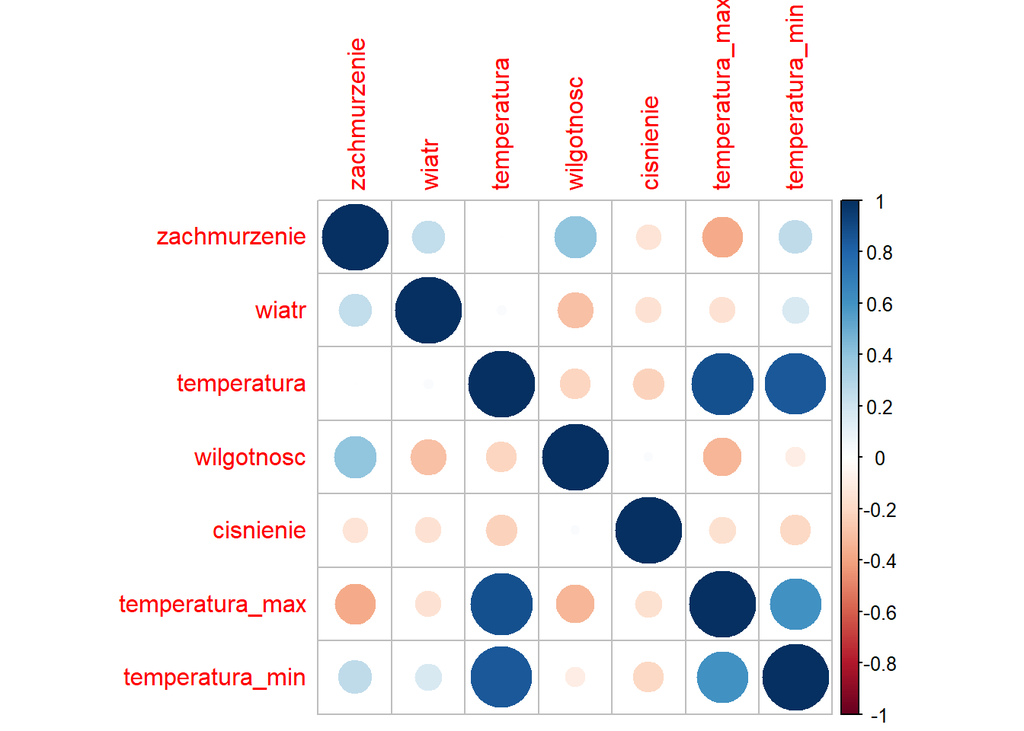

```r
corrplot(macierz_korelacji, method = "circle")
```

Wykresy pudełkowe i wykresy gęstości umożliwiają wizualne zrozumienie istotności predyktora poprzez sprawdzenie, w jakim stopniu wartości zmiennych numerycznych pokrywają się z przewidywaną zmienną opadów śniegu. Na wykresach pudełkowych odkryto takie zmienne, które nie wykazywały istotnych różnic między rozkładem z opadami śniegu a rozkładem bez opadów śniegu. Do tych zmiennych należy cisnienie oraz wilgotnosc. Z kolei wykresy pudełkowe zmiennych temperatura, temperatura minimalna, temperatura maksymalna, wiatr oraz zachmurzenie wykazały się istotnym zróżnicowaniem pod kątem zmiennej objaśnianej. Na przykład dla wykresu średniej prędkości wiatru, można zauważyć wyraźnie wyższą medianę oraz większy przedział wartości występujących prędkości wiatru podczas dni z opadami śniegu. Również wykresy gęstości pokazały, że wilgotność oraz ciśnienie nie wykazują większych różnic w dniach ze śniegiem oraz z jego brakiem. Brak wpływu ciśnienia atmosferycznego na opady śniegu może być spowodowany powstawaniem śniegu w górnych partiach troposfery, gdzie głównym czynnikiem determinującym wystąpienie śniegu jest temperatura. Z tego samego powodu, nawet niska wilgotność przy odpowiednio niskiej temperaturze może spowodować krystalizację pary wodnej, co w konsekwencji prowadzi do powstawania śniegu, ale nie wskazuje na różnicę w dniach bez i z występowaniem śniegu. W kosekwencji zmienne te nie będą brane pod uwagę podczas tworzenia modeli. Aby nie powielać kilku zmiennych opisujących to samo zjawisko atmosferycznę, wybrano średnią temperaturę dobową, zdefiniowaną jako zmienna temperatura. Charakteryzuje się ona największą zmiennością wykresu gęstości dni ze śniegiem oraz brakiem jego wystąpienia.

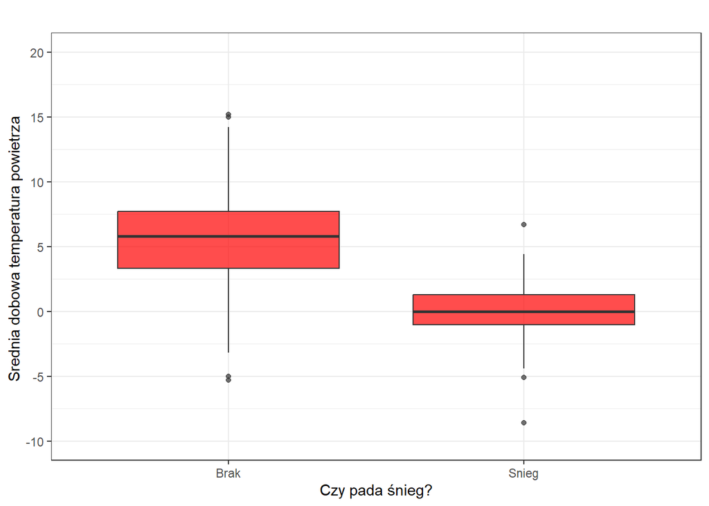

```r
dane_snieg %>% filter(!is.na(temperatura)) %>%
ggplot(., aes(x = snieg_prognoza, y = temperatura )) +
  geom_boxplot(fill = 'red',
               alpha = 0.7) +
  scale_y_continuous (name = "Srednia dobowa temperatura powietrza ",
                      breaks = seq (-10 , 20, 5) ,
                      limits =c(-10, 20) ) +
  scale_x_discrete(name = "Czy pada śnieg?") +
  ggtitle (" ") +
  theme_bw ()
```

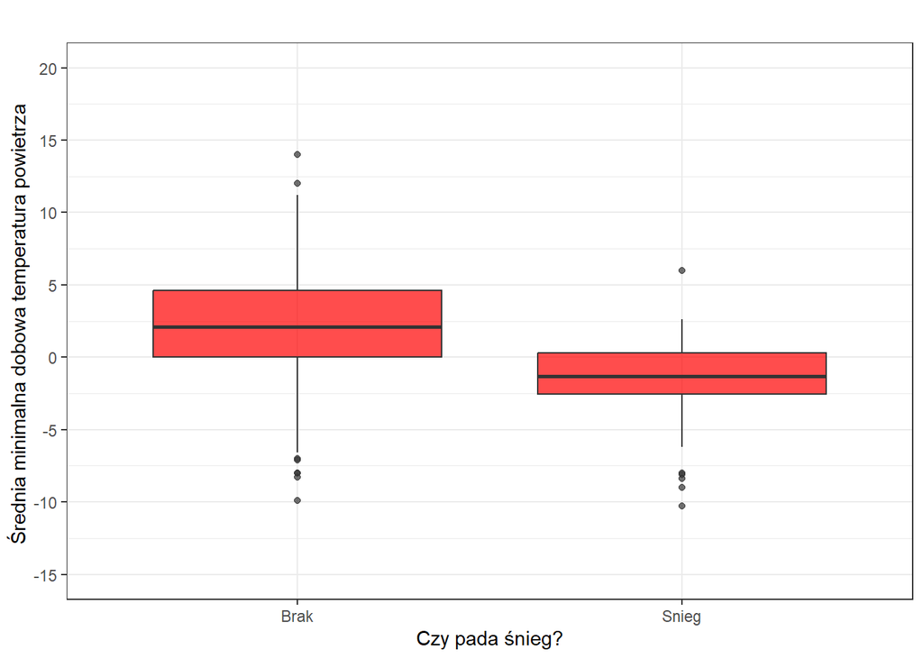

```r
dane_snieg %>% filter(!is.na(temperatura_min)) %>%
ggplot(., aes(x = snieg_prognoza, y = temperatura_min )) +
  geom_boxplot(fill = 'red',
               alpha = 0.7) +
  scale_y_continuous (name = "Średnia minimalna dobowa temperatura powietrza ",
                      breaks = seq (-15 , 20, 5) ,
                      limits =c(-15, 20) ) +
  scale_x_discrete(name = "Czy pada śnieg?") +
  ggtitle (" ") +
  theme_bw ()
```

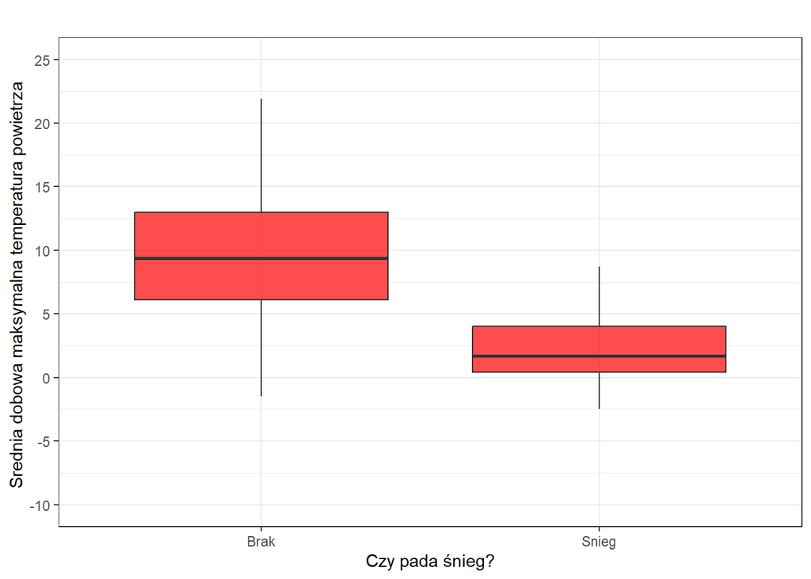

```r
dane_snieg %>% filter(!is.na(temperatura_max)) %>%
ggplot(., aes(x = snieg_prognoza, y = temperatura_max)) +
  geom_boxplot(fill = 'red',
               alpha = 0.7) +
  scale_y_continuous (name = "Srednia dobowa maksymalna temperatura powietrza ",
                      breaks = seq (-10, 25, 5) ,
                      limits =c(-10, 25) ) +
  scale_x_discrete(name = "Czy pada śnieg?") +
  ggtitle (" ") +
  theme_bw ()
```

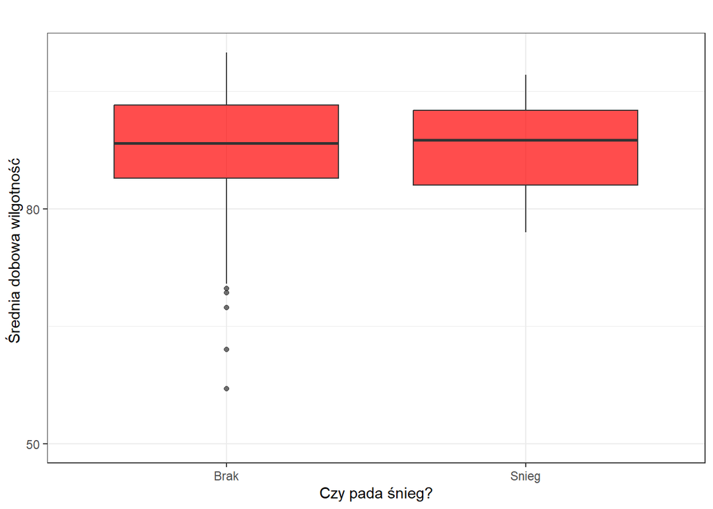

```r
dane_snieg %>% filter(!is.na(wilgotnosc)) %>%
ggplot(., aes(x = snieg_prognoza, y = wilgotnosc )) +
  geom_boxplot(fill = 'red',
               alpha = 0.7) +
  scale_y_continuous (name = "Średnia dobowa wilgotność ",
                      breaks = seq (50, 100, 30) ,
                      limits =c(50, 100) ) +
  scale_x_discrete(name = "Czy pada śnieg?") +
  ggtitle (" ") +
  theme_bw ()
```

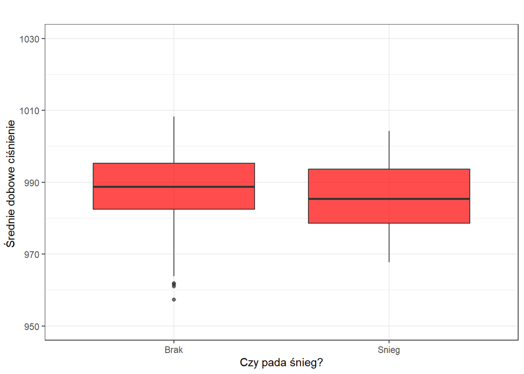

```r
dane_snieg %>% filter(!is.na(cisnienie)) %>%
ggplot(., aes(x = snieg_prognoza, y = cisnienie)) +
  geom_boxplot(fill = 'red',
               alpha = 0.7) +
  scale_y_continuous (name = "Średnie dobowe ciśnienie ",
                      breaks = seq (950, 1030, 20) ,
                      limits =c(950, 1030) ) +
  scale_x_discrete(name = "Czy pada śnieg?") +
  ggtitle (" ") +
  theme_bw ()
```

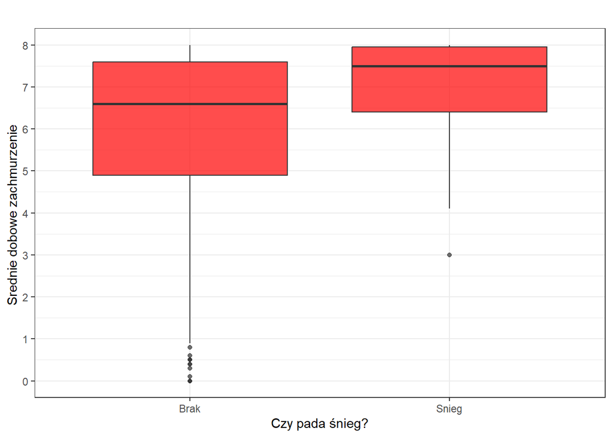

```r
dane_snieg %>% filter(!is.na(zachmurzenie)) %>%
ggplot(., aes(x = snieg_prognoza, y = zachmurzenie)) +
  geom_boxplot(fill = 'red',
               alpha = 0.7) +
  scale_y_continuous (name = "Srednie dobowe zachmurzenie ",
                      breaks = seq (0 , 9, 1) ,
                      limits =c(0, 8) ) +
  scale_x_discrete(name = "Czy pada śnieg?") +
  ggtitle (" ") +
  theme_bw ()
```

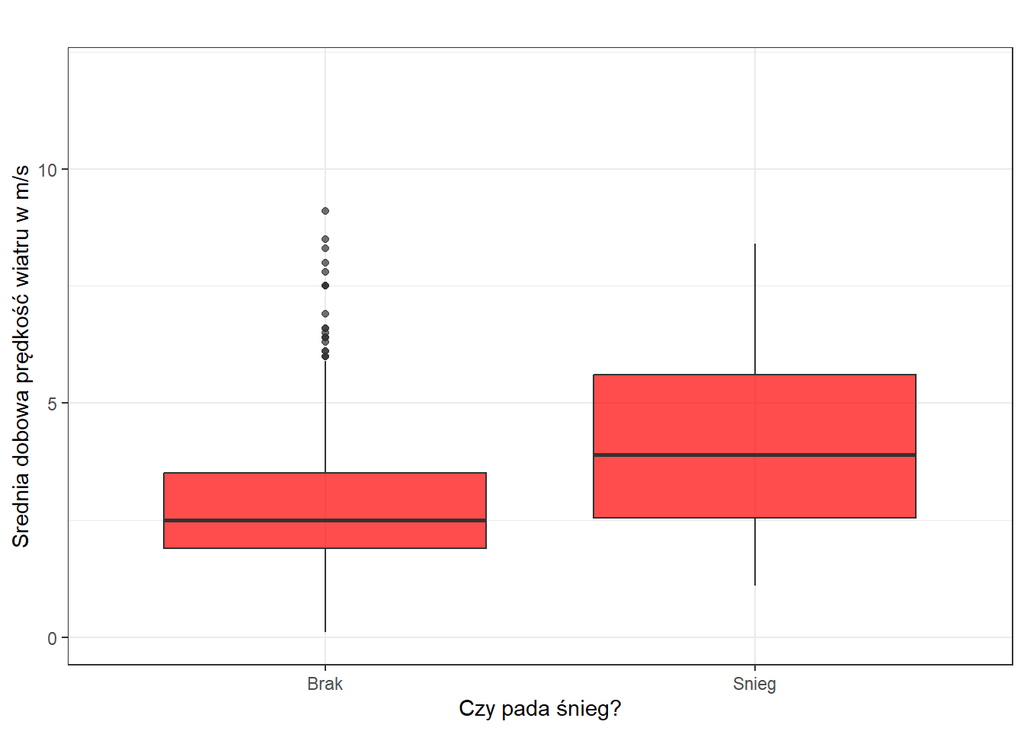

```r
dane_snieg %>% filter(!is.na(wiatr)) %>%
ggplot(., aes(x = snieg_prognoza, y = wiatr)) +
  geom_boxplot(fill = 'red',
               alpha = 0.7) +
  scale_y_continuous (name = "Srednia dobowa prędkość wiatru w m/s",
                      breaks = seq (0 , 12, 5) ,
                      limits =c(0, 12) ) +
  scale_x_discrete(name = "Czy pada śnieg?") +
  ggtitle (" ") +
  theme_bw ()
```

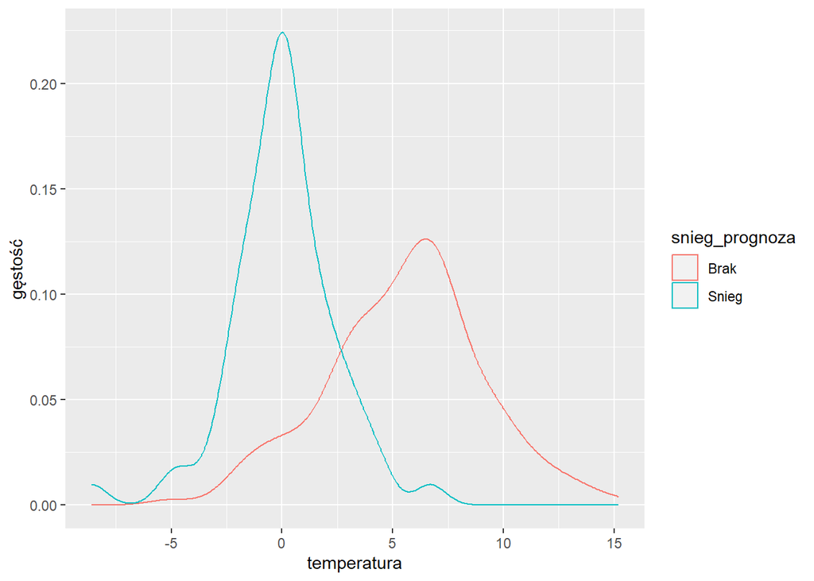

```r
ggplot(data = dane_snieg, aes(x = temperatura, col = snieg_prognoza)) +
  geom_density() +
  xlab("temperatura") + ylab("gęstość")
```

```r
  ggtitle("Wykres gęstości dla temperatury")
```

```
## $title
## [1] "Wykres gęstości dla temperatury"
##
## attr(,"class")
## [1] "labels"
```

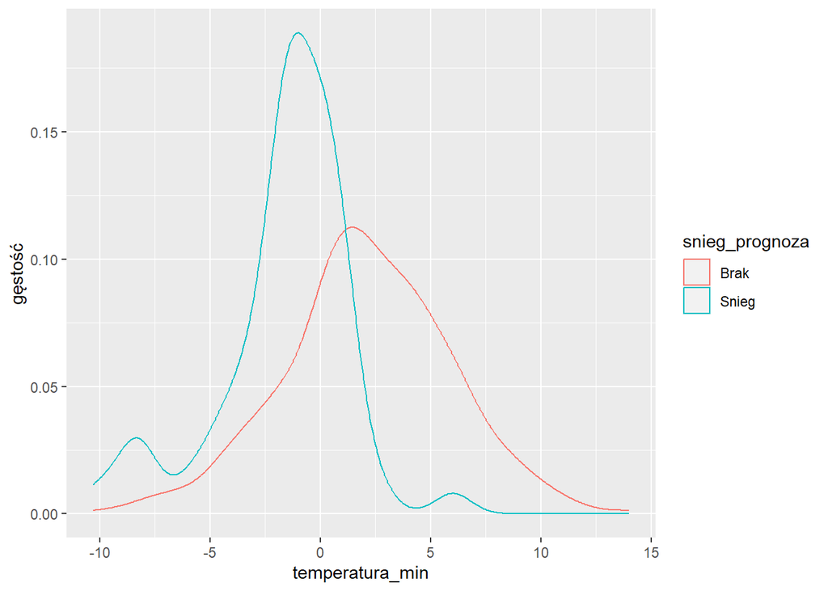

```r
ggplot(data = dane_snieg, aes(x = temperatura_min, col = snieg_prognoza)) +
  geom_density() +
  xlab("temperatura_min") + ylab("gęstość")
```

```r
  ggtitle("Wykres gęstości dla minimalnej temperatury")
```

```
## $title
## [1] "Wykres gęstości dla minimalnej temperatury"
##
## attr(,"class")
## [1] "labels"
```

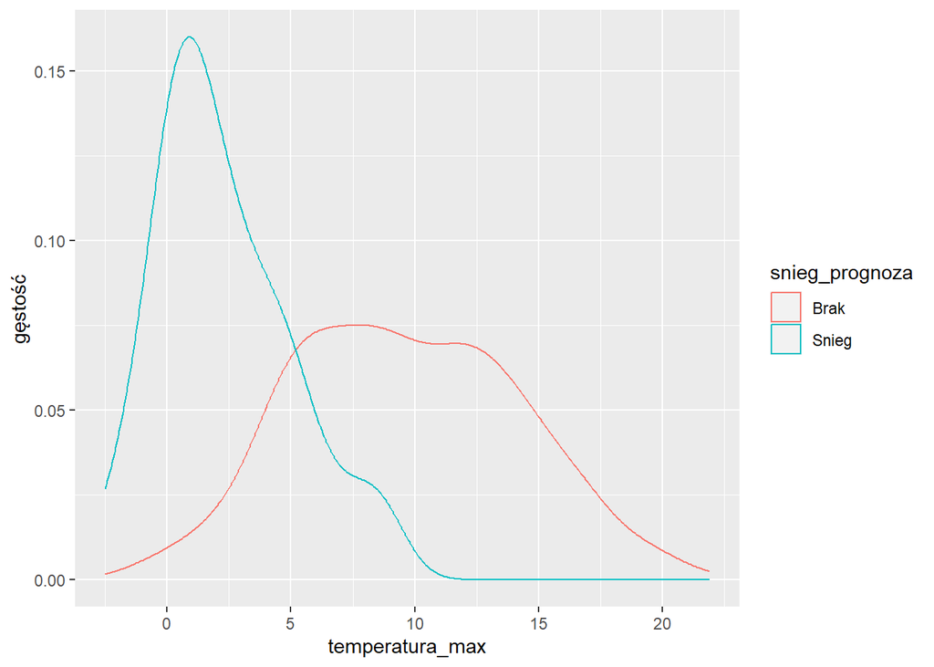

```r
ggplot(data = dane_snieg, aes(x = temperatura_max, col = snieg_prognoza)) +
  geom_density() +
  xlab("temperatura_max") + ylab("gęstość")
```

```r
  ggtitle("Wykres gęstości dla maksymalnej temperatury")
```

```
## $title
## [1] "Wykres gęstości dla maksymalnej temperatury"
##
## attr(,"class")
## [1] "labels"
```

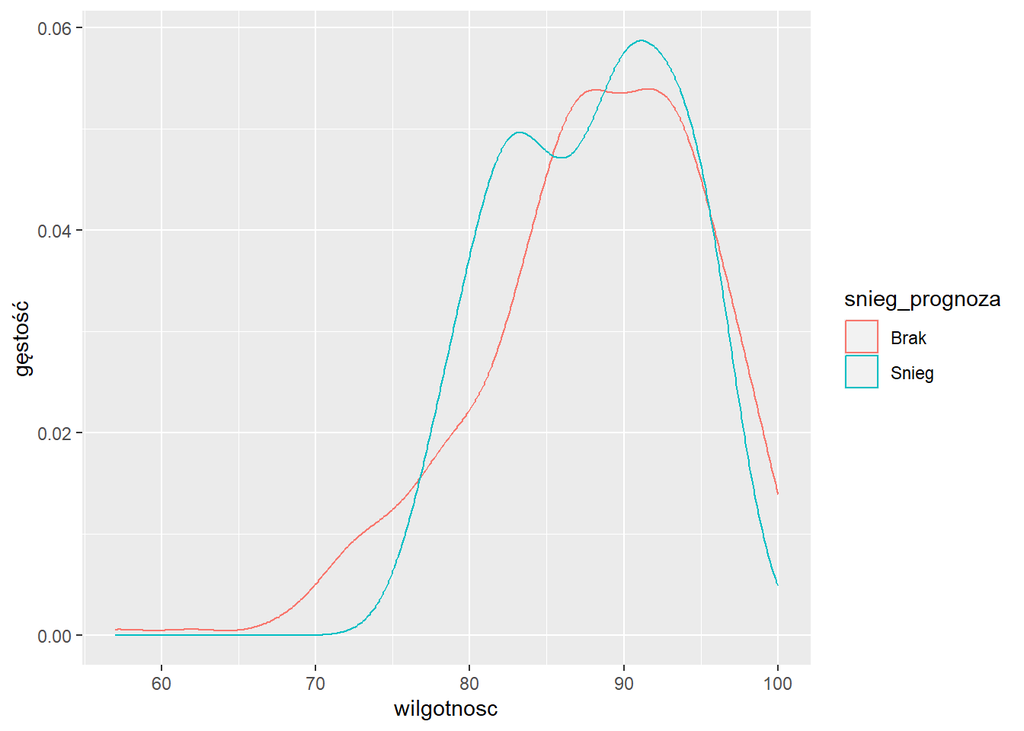

```r
ggplot(data = dane_snieg, aes(x = wilgotnosc, col = snieg_prognoza)) +
  geom_density() +
  xlab("wilgotnosc") + ylab("gęstość")
```

```r
  ggtitle("Wykres gęstości dla wilgotności")
```

```
## $title
## [1] "Wykres gęstości dla wilgotności"
##
## attr(,"class")
## [1] "labels"
```

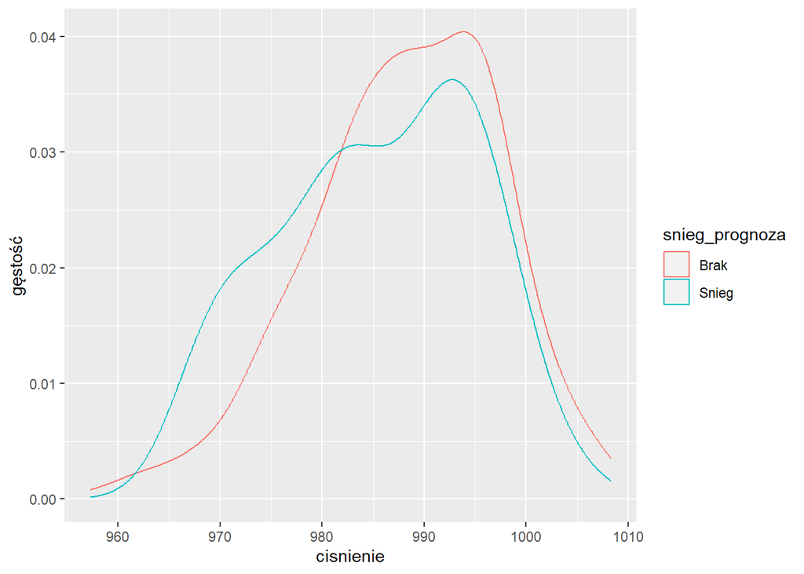

```r
ggplot(data = dane_snieg, aes(x = cisnienie, col = snieg_prognoza)) +
  geom_density() +
  xlab("cisnienie") + ylab("gęstość")
```

```r
  ggtitle("Wykres gęstości dla ciśnienia")
```

```
## $title
## [1] "Wykres gęstości dla ciśnienia"
##
## attr(,"class")
## [1] "labels"
```

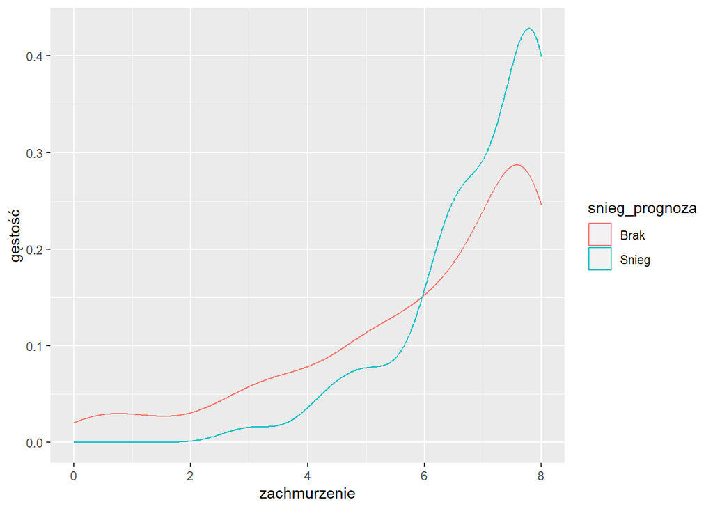

```r
ggplot(data = dane_snieg, aes(x = zachmurzenie, col = snieg_prognoza)) +
  geom_density() +
  xlab("zachmurzenie") + ylab("gęstość")
```

```r
  ggtitle("Wykres gęstości dla zachmurzenia")
```

```
## $title
## [1] "Wykres gęstości dla zachmurzenia"
##
## attr(,"class")
## [1] "labels"
```

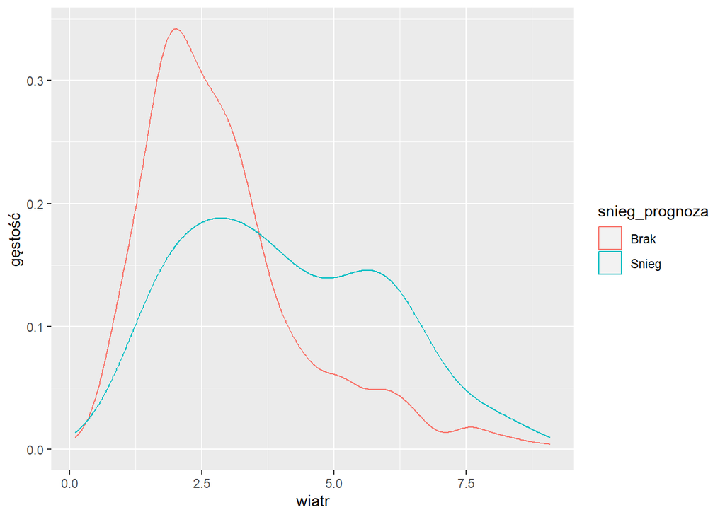

```r
ggplot(data = dane_snieg, aes(x = wiatr, col = snieg_prognoza)) +
  geom_density() +
  xlab("wiatr") + ylab("gęstość")
```

```r
  ggtitle("Wykres gęstości dla wiatru")
```

```
## $title
## [1] "Wykres gęstości dla wiatru"
##
## attr(,"class")
## [1] "labels"
```

```r
dane_snieg<- subset(dane_snieg, select = -c(temperatura_max, temperatura_min, cisnienie, wilgotnosc, wiatr10_01, zamglenie_01, zmetnienie_01))
colnames(dane_snieg)
```

```
## [1] "zachmurzenie"       "wiatr"              "temperatura"
## [4] "rosa_01"            "szron_01"           "mgla_01"
## [7] "pokrywa_sniezna_01" "deszcz_01"          "snieg_prognoza"
```

```r
str(dane_snieg)
```

```
## 'data.frame':    420 obs. of  9 variables:
##  $ zachmurzenie      : num  4.5 4.4 7.3 3.6 5.8 3.6 2.9 6.8 5.6 7.5 ...
##  $ wiatr             : num  3.3 3.5 5.1 2.6 1.8 6.9 2.6 3 1.8 1.8 ...
##  $ temperatura       : num  9.9 9.6 12.3 7.7 6 10.3 6.5 6.8 6.1 7.5 ...
##  $ rosa_01           : Factor w/ 2 levels "Brak","Rosa": 2 2 1 1 1 1 1 1 1 1 ...
##  $ szron_01          : Factor w/ 2 levels "Brak","Szron": 1 1 1 1 1 1 2 1 1 1 ...
##  $ mgla_01           : Factor w/ 2 levels "Brak","Mgla": 1 1 1 1 2 1 1 1 1 1 ...
##  $ pokrywa_sniezna_01: Factor w/ 2 levels "Brak","Pokrywa_sniezna": 1 1 1 1 1 1 1 1 1 1 ...
##  $ deszcz_01         : Factor w/ 2 levels "Brak","Deszcz": 1 2 1 1 2 1 2 2 1 2 ...
##  $ snieg_prognoza    : Factor w/ 2 levels "Brak","Snieg": 1 1 1 1 1 1 1 1 1 1 ...
```

```r
liczby <- table(dane_snieg$snieg_prognoza)
udzialy <- prop.table(liczby) * 100


cat("Liczba obserwacji w klasie pozytywnej (śnieg):", liczby["Snieg"], "\n")
```

```
## Liczba obserwacji w klasie pozytywnej (śnieg): 59
```

```r
cat("Liczba obserwacji w klasie negatywnej (brak śniegu):", liczby["Brak"], "\n")
```

```
## Liczba obserwacji w klasie negatywnej (brak śniegu): 361
```

```r
cat("Procentowy udział obserwacji w klasie pozytywnej (śnieg):", udzialy["Snieg"], "%\n")
```

```
## Procentowy udział obserwacji w klasie pozytywnej (śnieg): 14.04762 %
```

```r
cat("Procentowy udział obserwacji w klasie negatywnej (brak śniegu):", udzialy["Brak"], "%\n")
```

```
## Procentowy udział obserwacji w klasie negatywnej (brak śniegu): 85.95238 %
```

```r
calc_mode <- function(x){


  distinct_values <- unique(x)


  distinct_tabulate <- tabulate(match(x, distinct_values))

  distinct_values[which.max(distinct_tabulate)]
}
```

```r
set.seed(1234)
sample_set <- sample(nrow(dane_snieg), round(nrow(dane_snieg)*.70), replace = FALSE)
dane_treningowe <- dane_snieg[sample_set, ]
dane_testowe <- dane_snieg[-sample_set, ]
```

```r
table(dane_treningowe$snieg_prognoza)
```

```
##
##  Brak Snieg
##   256    38
```

```r
table(dane_testowe$snieg_prognoza)
```

```
##
##  Brak Snieg
##   105    21
```

```r
oversampled_dane_treningowe <- ovun.sample(snieg_prognoza ~ ., data = dane_treningowe, method = "over", N = 2*nrow(subset(dane_treningowe, dane_treningowe$snieg_prognoza == "Brak")))$data
table(oversampled_dane_treningowe$snieg_prognoza)
```

```
##
##  Brak Snieg
##   256   256
```

Regresja logistyczna Model regresji logistycznej został wykonany na danych treningowych, treningowych z oversamplingiem oraz danych testowych. Dokładność w dwóch pierwszych modelach jest wysoka, co świadczy że model dobrze radzi sobie z danymi treningowymi, jednak może to także świadczyć o nadmiernym dopasowaniu się danych. Współczynnik Kapppa, używany do oceny stopnia zgodności między dwoma zestawami klasyfikacji, predykcjami a wartościami rzeczywistymi, jest wyższy w przypadku danych z oversamplingiem. Jednak to w przypadku zwykłych danych treningowych, które nie są zbilansowane, jest bardziej przydatny. Czułość, którą można interpretować jako prawdopodobieństwo, że klasyfikacja będzie poprawna pod warunkiem, że przypadek jest pozytywny, jest wyższa w przypadku modelu z oversamplingiem. Z kolei specyficzność, czyli prawdopodobieństwo, że klasyfikacja będzie poprawna, pod warunkiem, że przypadek jest negatywny, jest wyższa w przypadku modelu niezbilansowanego. Można stwierdzić, że model z oversamplingiem może wydawać się lepszy, ponieważ radzi sobie lepiej z klasami mniejszościowymi, które są pożądane w badaniu.

```r
logistic_train <- glm(snieg_prognoza ~ ., data = dane_treningowe, family = "binomial")

logistic_train_over <- glm(snieg_prognoza ~ ., data = oversampled_dane_treningowe, family = "binomial")
logistic_predict_train <- predict(logistic_train, newdata = dane_treningowe, type = "response")

predicted_classes_train <- ifelse(logistic_predict_train > 0.5, "Snieg", "Brak")

cm <- confusionMatrix(as.factor(predicted_classes_train), as.factor(dane_treningowe$snieg_prognoza),
                      positive = "Snieg")

print(cm)
```

```
## Confusion Matrix and Statistics
##
##           Reference
## Prediction Brak Snieg
##      Brak   250    13
##      Snieg    6    25
##
##                Accuracy : 0.9354
##                  95% CI : (0.9009, 0.9606)
##     No Information Rate : 0.8707
##     P-Value [Acc > NIR] : 0.0002503
##
##                   Kappa : 0.6885
##
##  Mcnemar's Test P-Value : 0.1686686
##
##             Sensitivity : 0.65789
##             Specificity : 0.97656
##          Pos Pred Value : 0.80645
##          Neg Pred Value : 0.95057
##              Prevalence : 0.12925
##          Detection Rate : 0.08503
##    Detection Prevalence : 0.10544
##       Balanced Accuracy : 0.81723
##
##        'Positive' Class : Snieg
##
```

```r
logistic_predict_train_over <- predict(logistic_train_over, newdata = oversampled_dane_treningowe, type = "response")

predicted_classes_train_over <- ifelse(logistic_predict_train_over> 0.5, "Snieg", "Brak")

cm <- confusionMatrix(as.factor(predicted_classes_train_over), as.factor(oversampled_dane_treningowe$snieg_prognoza),
                      positive = "Snieg")
print(cm)
```

```
## Confusion Matrix and Statistics
##
##           Reference
## Prediction Brak Snieg
##      Brak   231    21
##      Snieg   25   235
##
##                Accuracy : 0.9102
##                  95% CI : (0.882, 0.9335)
##     No Information Rate : 0.5
##     P-Value [Acc > NIR] : <2e-16
##
##                   Kappa : 0.8203
##
##  Mcnemar's Test P-Value : 0.6583
##
##             Sensitivity : 0.9180
##             Specificity : 0.9023
##          Pos Pred Value : 0.9038
##          Neg Pred Value : 0.9167
##              Prevalence : 0.5000
##          Detection Rate : 0.4590
##    Detection Prevalence : 0.5078
##       Balanced Accuracy : 0.9102
##
##        'Positive' Class : Snieg
##
```

```r
logistic_test <- glm(snieg_prognoza ~ ., data = dane_testowe, family = "binomial")

logistic_predict_test <- predict(logistic_test, newdata = dane_testowe, type = "response")

predicted_classes_test <- ifelse(logistic_predict_test > 0.5, "Snieg", "Brak")

cm <- confusionMatrix(as.factor(predicted_classes_test), as.factor(dane_testowe$snieg_prognoza),
                      positive = "Snieg")
print(cm)
```

```
## Confusion Matrix and Statistics
##
##           Reference
## Prediction Brak Snieg
##      Brak   101     6
##      Snieg    4    15
##
##                Accuracy : 0.9206
##                  95% CI : (0.8589, 0.9613)
##     No Information Rate : 0.8333
##     P-Value [Acc > NIR] : 0.003467
##
##                   Kappa : 0.703
##
##  Mcnemar's Test P-Value : 0.751830
##
##             Sensitivity : 0.7143
##             Specificity : 0.9619
##          Pos Pred Value : 0.7895
##          Neg Pred Value : 0.9439
##              Prevalence : 0.1667
##          Detection Rate : 0.1190
##    Detection Prevalence : 0.1508
##       Balanced Accuracy : 0.8381
##
##        'Positive' Class : Snieg
##
```

```r
summary(logistic_test)
```

```
##
## Call:
## glm(formula = snieg_prognoza ~ ., family = "binomial", data = dane_testowe)
##
## Coefficients:
##                                   Estimate Std. Error z value Pr(>|z|)
## (Intercept)                        -4.0804     1.9621  -2.080 0.037558 *
## zachmurzenie                        0.4616     0.2641   1.748 0.080447 .
## wiatr                               0.0255     0.2337   0.109 0.913120
## temperatura                        -0.6785     0.1790  -3.790 0.000151 ***
## rosa_01Rosa                         0.5679     1.2792   0.444 0.657066
## szron_01Szron                       1.2893     1.1341   1.137 0.255580
## mgla_01Mgla                        -1.9209     1.1585  -1.658 0.097300 .
## pokrywa_sniezna_01Pokrywa_sniezna   1.2524     1.2792   0.979 0.327542
## deszcz_01Deszcz                     2.4053     0.9589   2.508 0.012131 *
## ---
## Signif. codes:  0 '***' 0.001 '**' 0.01 '*' 0.05 '.' 0.1 ' ' 1
##
## (Dispersion parameter for binomial family taken to be 1)
##
##     Null deviance: 113.541  on 125  degrees of freedom
## Residual deviance:  51.924  on 117  degrees of freedom
## AIC: 69.924
##
## Number of Fisher Scoring iterations: 7
```

```r
exp(coef(logistic_test))
```

```
##                       (Intercept)                      zachmurzenie
##                         0.0169008                         1.5865938
##                             wiatr                       temperatura
##                         1.0258302                         0.5073988
##                       rosa_01Rosa                     szron_01Szron
##                         1.7646100                         3.6302577
##                       mgla_01Mgla pokrywa_sniezna_01Pokrywa_sniezna
##                         0.1464780                         3.4987870
##                   deszcz_01Deszcz
##                        11.0821703
```

Interpretując model testowy regresji logistycznej można zauważyć, że zmiennymi istotnymi jest temperatura oraz deszcz. Temperatura jest oczywistym składnikiem pogody, który determinuje opady śniegu. Z kolei istostność opadów deszczu może być spowodowana ‘przechodzeniem’ opadów deszczu w opady śniegu, gdy temperatura maleje, wskazując że obie zmienne są ze sobą powiązane. Na podstawie ilorazu szans, można stwierdzić, że szansa wystąpienia opadów śniegu wzrasta o czynnik 11.082, przy opadach deszczu w ciągu tej samej doby.

```r
tree_train_gini <- rpart(snieg_prognoza ~ ., data = oversampled_dane_treningowe, method = "class", parms = list(split = "gini"), maxdepth = 4)

tree_train_gini
```

```
## n= 512
##
## node), split, n, loss, yval, (yprob)
##       * denotes terminal node
##
##  1) root 512 256 Brak (0.50000000 0.50000000)
##    2) temperatura>=3.45 192   7 Brak (0.96354167 0.03645833)
##      4) wiatr< 8.1 183   0 Brak (1.00000000 0.00000000) *
##      5) wiatr>=8.1 9   2 Snieg (0.22222222 0.77777778) *
##    3) temperatura< 3.45 320  71 Snieg (0.22187500 0.77812500)
##      6) wiatr< 3.05 106  51 Snieg (0.48113208 0.51886792)
##       12) pokrywa_sniezna_01=Brak 80  30 Brak (0.62500000 0.37500000)
##         24) zachmurzenie< 6.25 26   0 Brak (1.00000000 0.00000000) *
##         25) zachmurzenie>=6.25 54  24 Snieg (0.44444444 0.55555556) *
##       13) pokrywa_sniezna_01=Pokrywa_sniezna 26   1 Snieg (0.03846154 0.96153846) *
##      7) wiatr>=3.05 214  20 Snieg (0.09345794 0.90654206)
##       14) mgla_01=Mgla 21   8 Snieg (0.38095238 0.61904762)
##         28) temperatura>=-1.05 8   0 Brak (1.00000000 0.00000000) *
##         29) temperatura< -1.05 13   0 Snieg (0.00000000 1.00000000) *
##       15) mgla_01=Brak 193  12 Snieg (0.06217617 0.93782383) *
```

```r
tree_predict_train_gini <- predict(tree_train_gini, newdata = oversampled_dane_treningowe, type = "class")

confusionMatrix(tree_predict_train_gini, oversampled_dane_treningowe$snieg_prognoza, positive ="Snieg")
```

```
## Confusion Matrix and Statistics
##
##           Reference
## Prediction Brak Snieg
##      Brak   217     0
##      Snieg   39   256
##
##                Accuracy : 0.9238
##                  95% CI : (0.8973, 0.9453)
##     No Information Rate : 0.5
##     P-Value [Acc > NIR] : < 2.2e-16
##
##                   Kappa : 0.8477
##
##  Mcnemar's Test P-Value : 1.166e-09
##
##             Sensitivity : 1.0000
##             Specificity : 0.8477
##          Pos Pred Value : 0.8678
##          Neg Pred Value : 1.0000
##              Prevalence : 0.5000
##          Detection Rate : 0.5000
##    Detection Prevalence : 0.5762
##       Balanced Accuracy : 0.9238
##
##        'Positive' Class : Snieg
##
```

```r
tree_test_gini <- rpart(snieg_prognoza ~ ., data = dane_testowe, method = "class", parms = list(split = "gini"))

tree_test_gini
```

```
## n= 126
##
## node), split, n, loss, yval, (yprob)
##       * denotes terminal node
##
## 1) root 126 21 Brak (0.83333333 0.16666667)
##   2) temperatura>=1.8 98  4 Brak (0.95918367 0.04081633) *
##   3) temperatura< 1.8 28 11 Snieg (0.39285714 0.60714286)
##     6) mgla_01=Mgla 7  2 Brak (0.71428571 0.28571429) *
##     7) mgla_01=Brak 21  6 Snieg (0.28571429 0.71428571) *
```

```r
tree_predict_test_gini <- predict(tree_test_gini, newdata = dane_testowe, type = "class")

confusionMatrix(tree_predict_test_gini, dane_testowe$snieg_prognoza, positive ="Snieg")
```

```
## Confusion Matrix and Statistics
##
##           Reference
## Prediction Brak Snieg
##      Brak    99     6
##      Snieg    6    15
##
##                Accuracy : 0.9048
##                  95% CI : (0.8395, 0.9498)
##     No Information Rate : 0.8333
##     P-Value [Acc > NIR] : 0.01627
##
##                   Kappa : 0.6571
##
##  Mcnemar's Test P-Value : 1.00000
##
##             Sensitivity : 0.7143
##             Specificity : 0.9429
##          Pos Pred Value : 0.7143
##          Neg Pred Value : 0.9429
##              Prevalence : 0.1667
##          Detection Rate : 0.1190
##    Detection Prevalence : 0.1667
##       Balanced Accuracy : 0.8286
##
##        'Positive' Class : Snieg
##
```

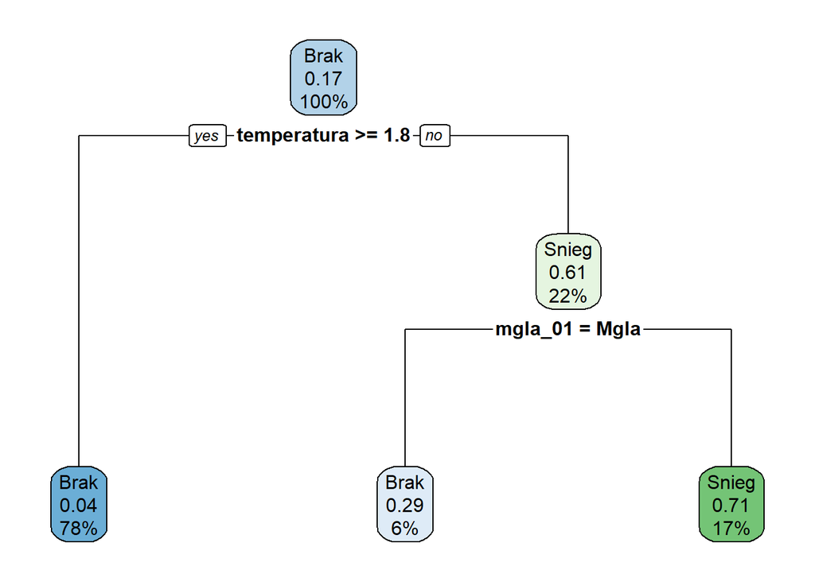

```r
rpart.plot(tree_test_gini)
```

Zinterpretowano model drzewa decyzyjnego, zbudowanego przy pomocy indeksu Giniego na danych testowych. Główną zmienną determinującą to czy wystąpią opady śniegu jest temperatura. Jeżeli wynosi więcej lub jest równa 1,8 stopni Celsjusza, z 96% prawdopodobieństwem nie wystąpią opady śniegu. Model wskazuje także, że w przypadku kiedy temperatura nie przekracza 1,8 stopni Celsjusza o wystąpieniu opadów śniegu może decydować występowanie mgły. Jeżeli jej nie ma, z 71% prawdopodobieństwem wystąpią opady śniegu. Tak jak wspomniano przy interpretacji regresji logistycznej, temperatura jest główną zmienną, która może wskazywać na występowanie opadów śniegu. Z kolei zgodnie z prawami cyrkulacji atmosfery, mgła może być czynnkiem, który nie sprzyja opadom śniegu ze względu na działanie przybliżone do warstwy chmur, absorbując lub rozpraszając promieniowanie słoneczne. Jeśli mgła utrzymuje się przez dłuższy czas, może wpływać na ogrzewanie powierzchni, co z kolei szybciej spowoduje opady deszczu niż śniegu.

```r
tree_train_entropia <- rpart(snieg_prognoza ~ ., data = oversampled_dane_treningowe, method = "class", parms = list(split = "information"), maxdepth = 4)
tree_train_entropia
```

```
## n= 512
##
## node), split, n, loss, yval, (yprob)
##       * denotes terminal node
##
##  1) root 512 256 Brak (0.50000000 0.50000000)
##    2) temperatura>=4.25 171   0 Brak (1.00000000 0.00000000) *
##    3) temperatura< 4.25 341  85 Snieg (0.24926686 0.75073314)
##      6) wiatr< 3.05 116  55 Brak (0.52586207 0.47413793)
##       12) temperatura>=2.65 26   0 Brak (1.00000000 0.00000000) *
##       13) temperatura< 2.65 90  35 Snieg (0.38888889 0.61111111)
##         26) pokrywa_sniezna_01=Brak 64  30 Brak (0.53125000 0.46875000) *
##         27) pokrywa_sniezna_01=Pokrywa_sniezna 26   1 Snieg (0.03846154 0.96153846) *
##      7) wiatr>=3.05 225  24 Snieg (0.10666667 0.89333333) *
```